# AI Training Gaps in European Schools

Author

Ana Nenadic

```r
library(tidyverse)
```

My data is from the OECD [Teaching and Learning International Survey (TALIS) 2024](https://www.oecd.org/en/publications/results-from-talis-2024_90df6235-en/full-report/list-of-tables-available-online_d5b208db.html). Specifically, training gap data is from table 4.30; barriers to AI use is from table 1.63 for middle school teachers across a selection of 28 European countries, further stratified by EU member, EU candidate, and non-member or candidate.

## Graph 1: Teacher AI Training Gap by Country

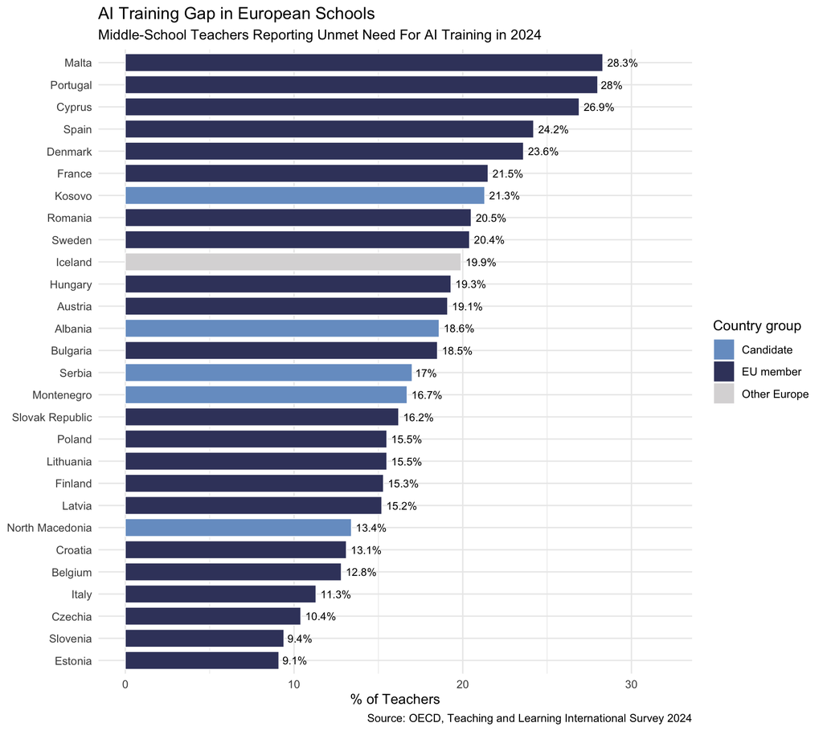

```r
gap <- read_csv("data/training_gap.csv")

#My EU Color Palette
darkblue <- "#3D426B" #for EU member states
lightblue <- "#779ECB" #for Candidate states
grey <- "#DBD9DA"# for non-EU and non-Candidate states
black <- "#000000" #. for general text labels

ggplot(gap, aes (x = reorder(country, training_gap_pct),
                 y = training_gap_pct, fill = group)) +
      geom_col(width=0.8, color = "white", linewidth = 0.3) +
      geom_text (aes(label = paste0(training_gap_pct, "%")),
                 hjust = -0.15, size = 3, color = black) +
      coord_flip() +
      scale_fill_manual(values = c("EU member" = darkblue,
                                   "Candidate" = lightblue,
                                   "Other Europe" = grey)) +
      scale_y_continuous(limits = c(0,32)) +
      labs(title = "AI Training Gap in European Schools",
           subtitle = "Middle-School Teachers Reporting Unmet Need For AI Training in 2024",
           x = NULL, y = "% of Teachers",
           fill = "Country group",
           caption = "Source: OECD, Teaching and Learning International Survey 2024") +

      theme_minimal()
```

Some Southern European countries have the biggest gaps between need and presence of training: Malta (28.3%), Cyprus (26.9%), and Spain (24.2%). Estonia (9.1%) and several Central European countries like Slovenia (9.4%) and the Czech Republic (10.4%) have the smallest gaps. Meanwhile, EU membership does not delineate the countries since there is a wide range among member states (from 9.1% to 28.3%). Western Balkan candidate countries like Kosovo (21.3%) and North Macedonia (13.4%) are also within that spectrum. This chart is helpful in understanding that EU membership does not necessarily predict how well teacher needs for AI training are met.

## Graph 2: Teacher AI Training Gap Across Years of Teaching

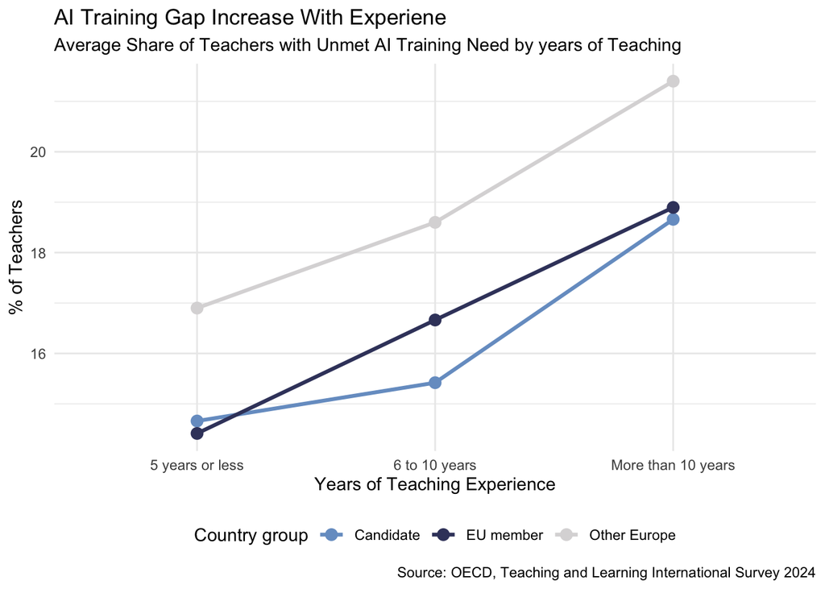

```r
exp_gap <- read_csv("data/experience_gap.csv")

by_group <- exp_gap |>
  group_by(group) |>
  summarise(le5 = mean(le5_pct), y6_10 = mean(y6_10_pct), gt10 = mean(gt10_pct)) |>
  pivot_longer(cols = c(le5, y6_10,gt10),
               names_to = "experience", values_to ="avg_pct") |>
  mutate(experience = factor(experience, levels = c("le5", "y6_10", "gt10"),
                             labels = c("5 years or less", "6 to 10 years", "More than 10 years")))

ggplot(by_group, aes(x = experience, y = avg_pct, color = group, group = group)) +
  geom_line(linewidth = 1.1) +
  geom_point(size = 3) +
  scale_color_manual(values = c("EU member" = darkblue,
                                "Candidate" = lightblue,
                                "Other Europe" = grey)) +
  labs(title = "AI Training Gap Increase With Experiene",
       subtitle = "Average Share of Teachers with Unmet AI Training Need by years of Teaching",
       x = "Years of Teaching Experience", y = "% of Teachers",
       color = "Country group",
       caption = "Source: OECD, Teaching and Learning International Survey 2024") +

  theme_minimal() +
  theme(legend.position = "bottom")
```

Across the three categories of states in Europe, the share of middle school teachers that report unmet AI training need rises with teaching experience. Specifically, within the EU member state category, those teachers with 5 years or fewer of teaching experience roughly report around 14.4% and those that had more than 10 years report up to 18.9%. Within the EU candidate state category, the difference is similar. On the one end, we have a range from 14.7% to 18.7%. This chart is helpful in understanding that those teachers with most significant experience teaching are, also most likely to report recieving inadequate training; state-wide, and EU-wide, programs can benefit from this information for targeting purposes.

## Graph 3: Teachers’ Barriers to AI Use

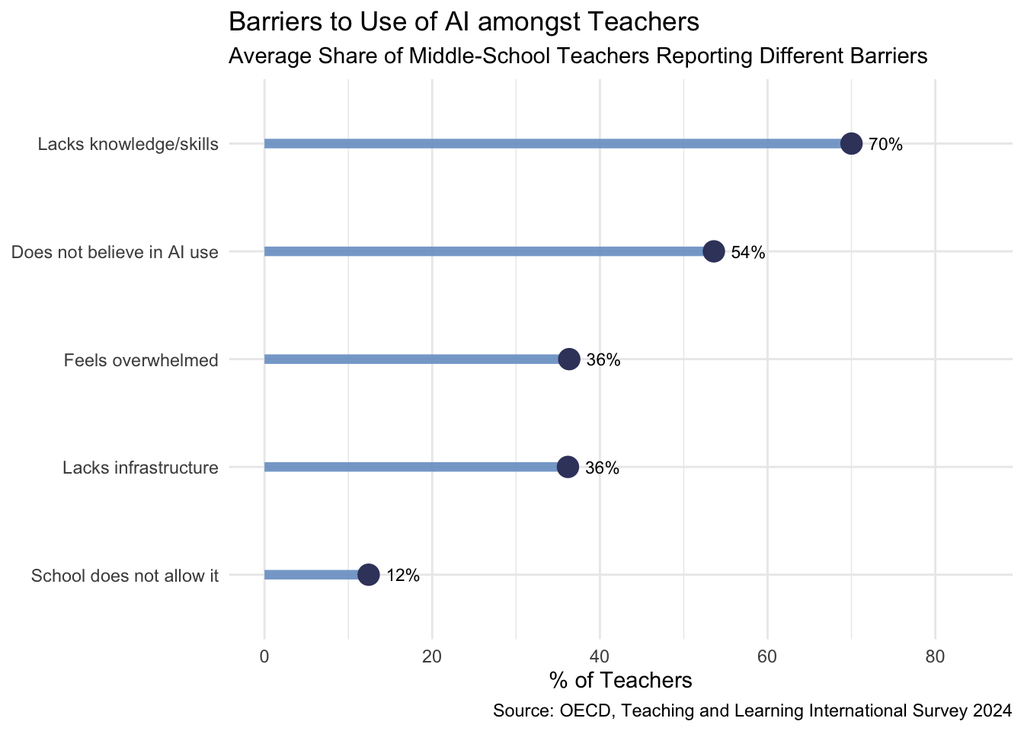

```r
barriers <- read_csv("data/barriers.csv")

#My EU Color Palette
darkblue <- "#3D426B" #for EU member states
lightblue <- "#779ECB" #for Candidate states
grey <- "#DBD9DA"# for non-EU and non-Candidate states
black <- "#000000" # for general text labels

avg_barriers <- barriers |>
  pivot_longer (cols = -c(country, group), names_to = "barrier", values_to = "pct" ) |>
  group_by(barrier) |>
  summarise(avg_pct = mean(pct)) |>
  arrange(avg_pct)

avg_barriers$barrier <- factor(avg_barriers$barrier, levels = avg_barriers$barrier)

ggplot(avg_barriers, aes(x = avg_pct, y = barrier)) +
  geom_segment(aes(x=0, xend = avg_pct, y = barrier, yend = barrier),
    color = lightblue, linewidth = 2.2, alpha = 0.9) +
  geom_point(size = 4.5, color = darkblue) +
  geom_text(aes(label=paste0(round(avg_pct), "%")),
            hjust = -0.5, size = 3, color = black) +
  scale_x_continuous(limits = c(0,85)) +
  labs(title = "Barriers to Use of AI amongst Teachers",
       subtitle = "Average Share of Middle-School Teachers Reporting Different Barriers",
       x = "% of Teachers", y = NULL,
       caption = "Source: OECD, Teaching and Learning International Survey 2024") +

  theme_minimal()
```

Across 28 European countries, the most likely barrier that middle school teacher report in their use of AI in teaching is a lack of proper knowledge and skills at about 70%. The second most likely barrier is tied to their beliefs; 54% of these teachers indicate that they are opposed to the use of AI in teaching practices. The third and fourth most reported barriers are the general feeling of overwhelm by the new technologies and inadequate infrastructure in school facilities, both at around 36%. Interestingly, only 12% of teachers report that their school prohibits AI. This chart is helpful in understanding that even if AI training were improved and expanded, a significant portion of European middle school teachers would not use the technology because of their beliefs.

## Graph 4: Spread of AI Training Gap Across Countries

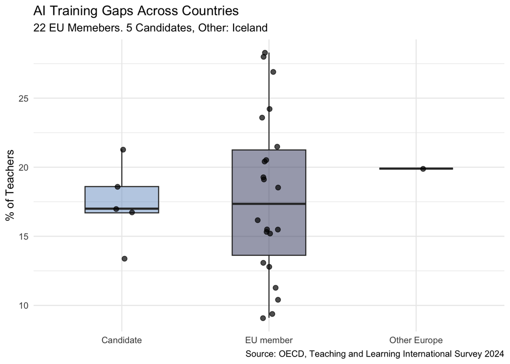

```r
gap <- read_csv("data/training_gap.csv")

#My EU Color Palette
darkblue <- "#3D426B" #for EU member states
lightblue <- "#779ECB" #for Candidate states
grey <- "#DBD9DA"# for non-EU and non-Candidate states
black <- "#000000" #. for general text labels

ggplot(gap,aes(x= group, y = training_gap_pct, fill = group)) +
  geom_boxplot(width = 0.5, alpha = 0.5, outlier.shape = NA) +
  geom_jitter(width = 0.08, size = 2, color = black, alpha = 0.7) +
  scale_fill_manual(values = c("EU member" = darkblue,
                                "Candidate" = lightblue,
                                "Other Europe" = grey)) +
  guides(fill = "none") +
  labs(title = "AI Training Gaps Across Countries",
       subtitle = "22 EU Memebers. 5 Candidates, Other: Iceland",
        x = NULL, y = "% of Teachers",
        caption = "Source: OECD, Teaching and Learning International Survey 2024") +
  theme_minimal()
```

From the European states across the three categories, the share of teacher that report unmet AI training needs has a highest variation within EU member states than the other two categories. Specifically, 22 EU member states have a range from 9.1% (Estonia) to 28.3% (Malta). Meanwhile, the 5 candidate states range from 13.4% (North Macedonia) to 21.3% (Kosovo). The median for EU members is 17.4% and for candidate states it is similar, at about 17.0%; Iceland, that forms the Other category, is at 19.9%. This chart is helpful in understanding that EU membership is not indicative of differences in AI-training, which means that programming aimed at teachers should not be carried out uniformly within the groups.

## Graph 5: Barriers to AI for Teachers Across Europe

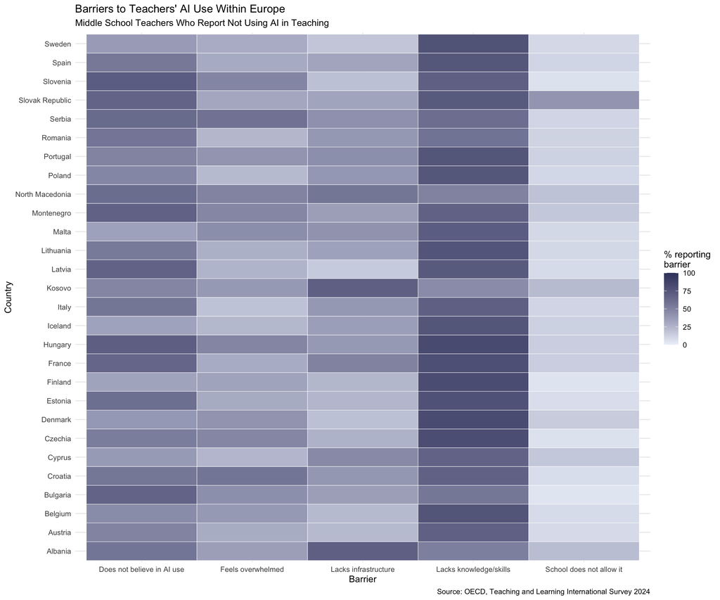

```r
barriers <- read_csv("data/barriers.csv")

#My EU Color Palette
darkblue <- "#3D426B" #for EU member states
lightblue <- "#779ECB" #for Candidate states
grey <- "#DBD9DA"# for non-EU and non-Candidate states
black <- "#000000" # for general text labels
paleblue <- "#EDF2FA" # for low % for heatmap

heatmap_data <- barriers |>
  pivot_longer(
    cols = -c(country,group),
    names_to = "barrier",
    values_to = "pct"
  )
ggplot(heatmap_data,aes(x = barrier, y = country, fill = pct)) +
  geom_tile(color = "white") +
  scale_fill_gradient(
    low = paleblue,
    high = darkblue,
    limits = c(0,100),
    na.value = grey
  ) +
  labs(title = "Barriers to Teachers' AI Use Within Europe",
       subtitle = "Middle School Teachers Who Report Not Using AI in Teaching",
        x = "Barrier", y = "Country", fill = "% reporting\nbarrier",
        caption = "Source: OECD, Teaching and Learning International Survey 2024") +
  theme_minimal()
```

## Visualization Requirements Checklist

| Requirement Category | Specific Element / Code Used | Graph # (1, 2, 3, 4, or 5) |
| --- | --- | --- |
| **Geom 1** | geom_col() | 1 |
| **Geom 2** | geom_text() | 1 and 3 |
| **Geom 3** | geom_line() | 2 |
| **Geom 4** | geom_point() | 2 and 3 |
| **Geom 5** | geom_segment() | 3 |
| **Geom 6** | geom_tile() | 5 |
| **Aesthetic 1** *(inside `aes()`)* | x | 1 and 2 and 3 and 4 and 5 |
| **Aesthetic 2** *(inside `aes()`)* | y | 1 and 2 and 3 and 4 and 5 |
| **Aesthetic 3** *(inside `aes()`)* | fill | 1 and 4 and 5 |
| **Aesthetic 4** *(inside `aes()`)* | color | 2 |
| **Aesthetic 5** *(inside `aes()`)* | label | 1 and 3 |
| **Aesthetic 6** *(inside `aes()`)* | group | 2 |
| **Non-Aesthetic 1** *(outside `aes()`)* | width | 1 and 4 |
| **Non-Aesthetic 2** *(outside `aes()`)* | hjust | 1 and 3 |
| **Non-Aesthetic 3** *(outside `aes()`)* | size | 1 and 2 and 3 and 4 |
| **Non-Aesthetic 4** *(outside `aes()`)* | linewidth | 1 and 2 and 3 |
| **Non-Aesthetic 5** *(outside `aes()`)* | alpha | 3 and 4 |
| **Non-Aesthetic 6** *(outside `aes()`)* | outlier.shape | 4 |
| **Non-Aesthetic 7** *(outside `aes()`)* | color | 1 and 3 and 4 and 5 |
| **Custom Scale 1** | scale_fill_manual() | 1 and 4 |
| **Custom Scale 2** | scale_color_manual() | 2 |
| **Custom Scale 3** | scale_fill_gradient() | 5 |